# Differential Gene Expression of Plasma Cell Subsets

Brian Gaudette

Saturday, August 1, 2015

## Abstract

Plasma cells (PCs) can be grouped into subsets based on the isotype of the antibody they secrete, their phenotype including maturity and their survival niche in the body. In this study we examined differential gene expression in several of these subsets. We sorted PCs from lamina propria (LP), bone marrow (BM) and spleens (SPL) collected from three wild type C57Bl/6 mice from which we prepared RNA to analyse by microarray. We further split BM and SPL samples into B220+ and B220- subsets while all LP PCs used were B220-. We also sorted folicular B cells from these mice for a total of 3 samples from each of 6 groups for a total of 18 samples. The following report includes normalization data, exploratory principle component analysis and differentially expressed gene analysis for two experimental conditions. These were examination of the effect of organ of residence of mature, B220- PCs and examination of the effect of maturity in both BM and SPL PCs comparing B220- and B220+ subsets.

## R packages

**These R/bioconductor packages were used to complete the analysis of these Affy1.0 arrays.**

```r
library(oligo)
library(affycoretools)
library(pd.mogene.1.0.st.v1)
library(mogene10sttranscriptcluster.db)
library(RColorBrewer)
library(gplots)
library(ggplot2)
library(genefilter)
library(limma)
library(annotate)
library(reshape2)
library(Biobase)
```

**This report was compiled in Rmarkdown using these packages:**

```r
library(rmarkdown)
library(knitr)
library(devtools)
```

## Experimental set up and Quality Control

**First read in a textfile containing the experimental design and assign sample names**

```r
targets <- read.delim("allmanArray_4821_studyDesignFile.txt", sep="\t", stringsAsFactors = FALSE)
sampleLabels <- as.character(paste(targets$Tissue, targets$cellType, targets$B220, targets$replicate, sep="."))
myGroups <- factor(paste(targets$Tissue, targets$cellType, targets$B220, sep="."))
```

**Now read in and normalize the raw data from the CEL files**

```r
rawData <- read.celfiles(list.celfiles())
normData <- oligo::rma(rawData, target="core")
```

#### **Figure 1: Histogram of signal intensity across each array before (A) and after normalization (B)**

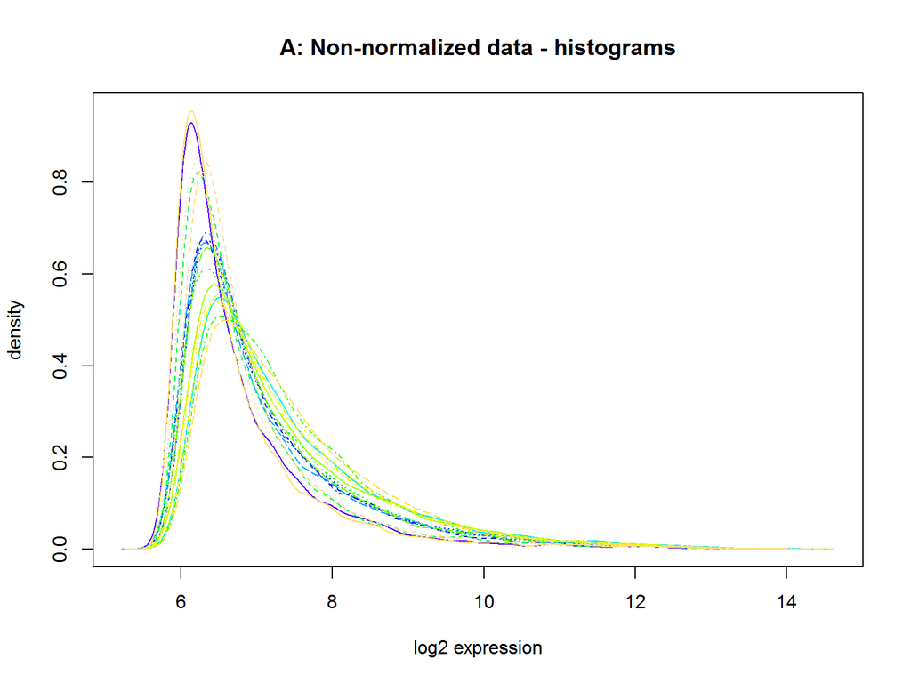

```r
cols <- topo.colors (n=18, alpha=1)
hist(rawData, xlab = "log2 expression", main = "A: Non-normalized data - histograms", col=cols)
```

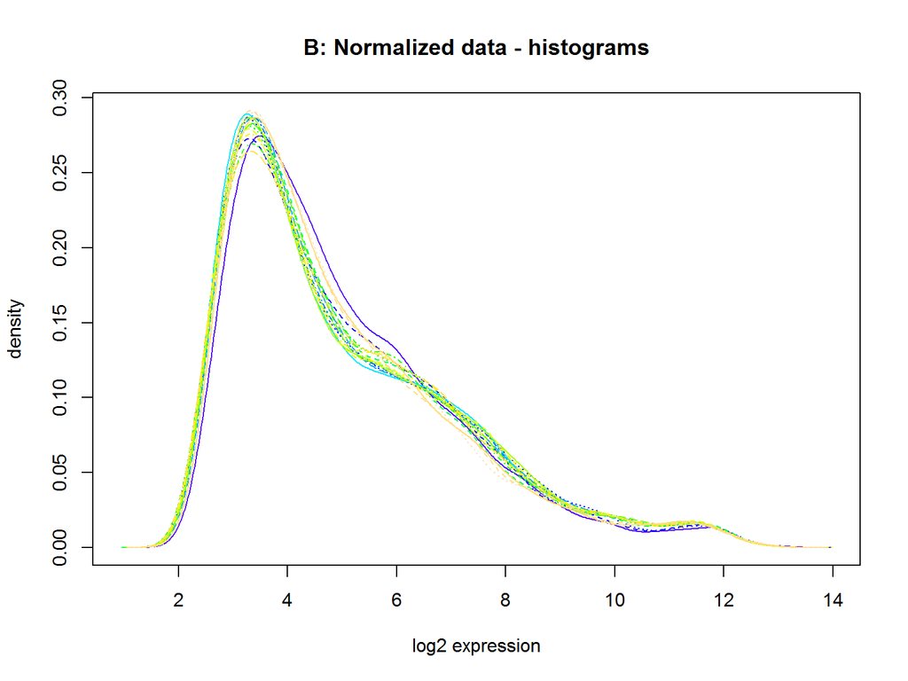

```r
hist(normData, xlab = "log2 expression", main = "B: Normalized data - histograms", col=cols)
```

#### **Figure 2: Box plot representation of raw (A) and normalized (B) data**

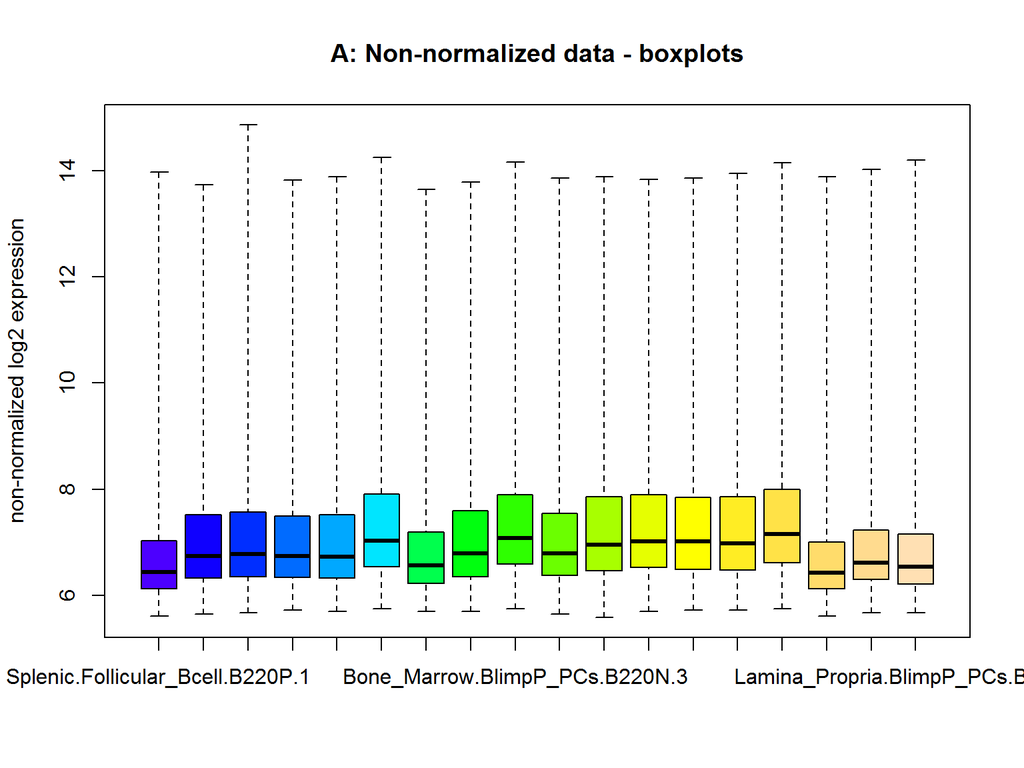

```r
boxplot(rawData, names = sampleLabels, ylab = "non-normalized log2 expression",
        main = "A: Non-normalized data - boxplots", col=cols)
```

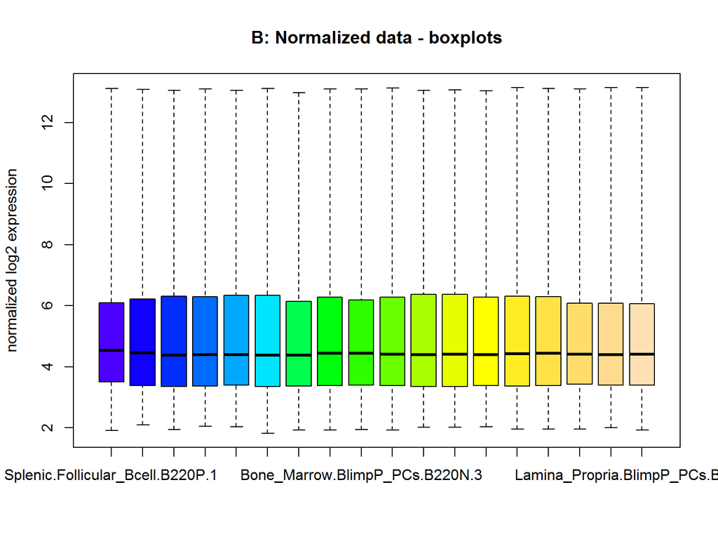

```r
boxplot(normData, names = sampleLabels, ylab = "normalized log2 expression",
        main = "B: Normalized data - boxplots", col=cols)
```

**Now filter the data to remove control probes and duplicates keeping probes with max signal.**  
**Also remove probes not detected over background or with low varience over all samples.**  
**Create a datamatrix containing the normalized filtered data.**

```r
normData.main <- getMainProbes(normData)
normData.main.matrix <- exprs(normData.main)
annotation(normData) <- "mogene10sttranscriptcluster.db"
filtered_geneList <- nsFilter(normData, var.func=IQR, var.filter=TRUE, var.cutoff=0.5, filterByQuantile=TRUE, feature.exclude="^AFFX")
filtered.eset <- filtered_geneList$eset
filtered.matrix <- as.matrix(filtered.eset)
probeList <- rownames(filtered.matrix)
```

**Discussion 1:** The raw data looks pretty good and the normalization seems to be satisfactory. After normalization and filtering there are **10431** genes in the data set.

## Data Exploration

**Now hierarchical clustering and principle component analysis of the data**

#### **Figure 3. Hierarchical clustering of plasma cell subsets.**

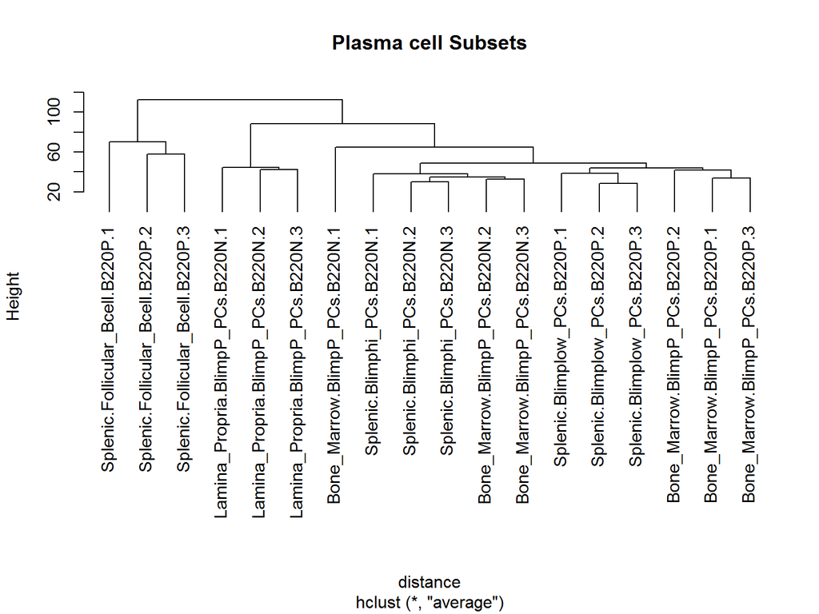

```r
distance <- dist(t(filtered.matrix),method="euclidian")
clusters <- hclust(distance, method = "average")
plot(clusters, label = sampleLabels, hang = -1, main="Plasma cell Subsets")
```

**Discussion 2a:** The sample Bone_Marrow.BlimpP.B220N.1 is not clustering with its biological replicates. Furthermore, it appears to be less similar to its replicates than all of the other PC samples except LP PCs.

#### **Figure 4. Principle component analysis showing that the bulk of the varience is accounted for in pc1 and pc2**

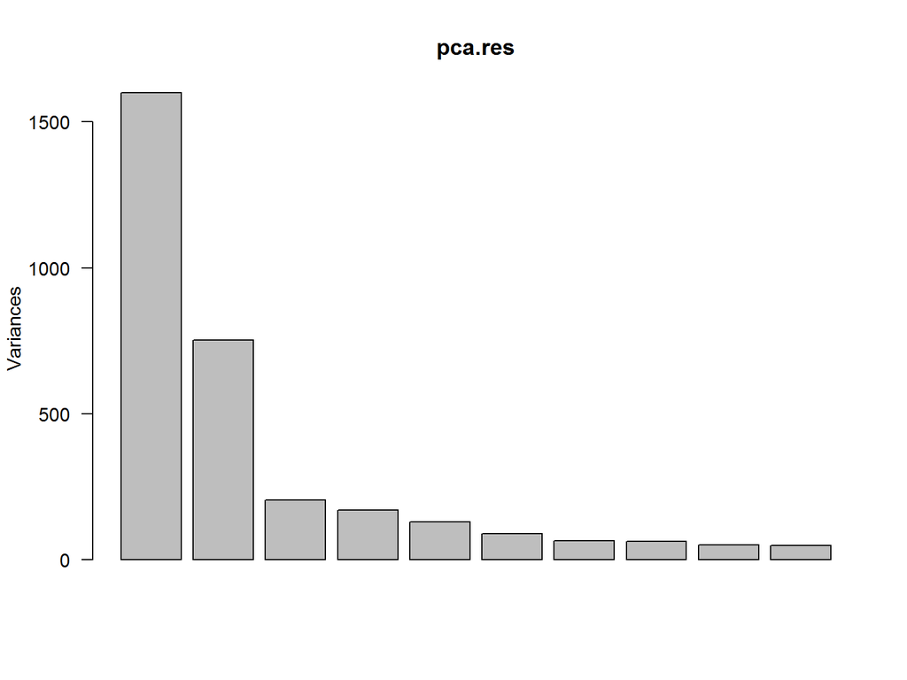

```r
pca.res <- prcomp(t(filtered.matrix), scale.=F, retx=T)
ls(pca.res)
summary(pca.res)
head(pca.res$rotation)
head(pca.res$x)
plot(pca.res, las=1)
```

numerical contribution of PCs to total variance

```r
pc.var<-pca.res$sdev^2
pc.per<-round(pc.var/sum(pc.var)*100, 1)
pc.per
```

```
##  [1] 47.4 22.3  6.0  5.0  3.8  2.6  1.9  1.8  1.5  1.4  1.3  1.1  1.0  0.8
## [15]  0.7  0.7  0.6  0.0
```

#### **Figure 5. Contibution of samples to PC1 and PC2.**

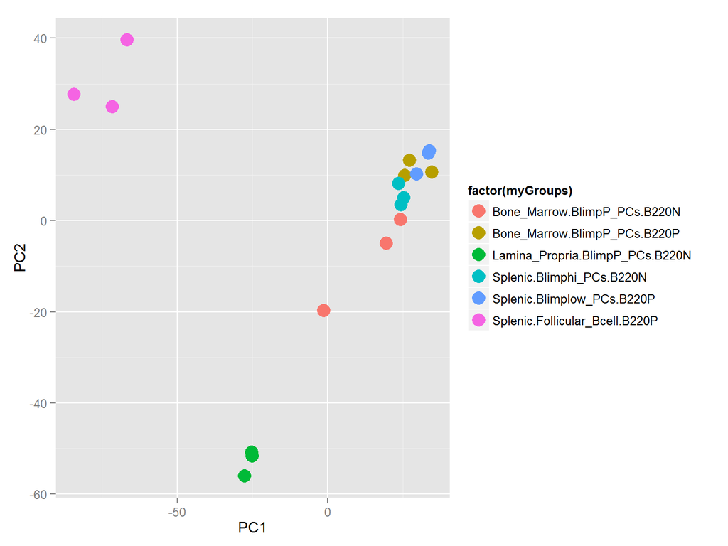

```r
data.frame <- as.data.frame(pca.res$x)
ggplot(data.frame, aes(x=PC1, y=PC2, colour=factor(myGroups))) +
  geom_point(size=5) +
  theme(legend.position="right")
```

#### **Figure 6. Small multiples chart to examine the contribution of each experimental variable on each PC.**

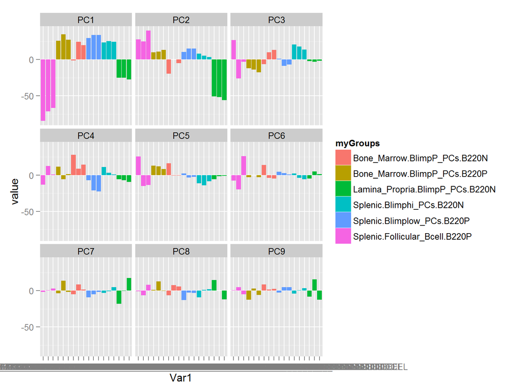

```r
melted <- cbind(myGroups, melt(pca.res$x[,1:9]))
ggplot(melted) +
  geom_bar(aes(x=Var1, y=value, fill=myGroups), stat="identity") +
  facet_wrap(~Var2)
```

## Differentially Expressed Genes 1: Lamina Propria PCs

**Now set up the experimental design and think about the question to ask in this analysis.**  
The bulk of the variability in the PC groups was between Lamina propria and all other plasma cells so let’s look there first.

```r
design <- model.matrix(~0+myGroups)
colnames(design) <- levels(myGroups)
design
```

Define the contrast matrix and look at differentially expressed genes.

```r
fit <- lmFit(filtered.matrix, design)
fit$genes$Symbol <- getSYMBOL(probeList, "mogene10sttranscriptcluster.db")
fit$genes$Entrez <- getEG(probeList, "mogene10sttranscriptcluster.db")
contrast.matrix.LP <- makeContrasts(LPvBM = Lamina_Propria.BlimpP_PCs.B220N - Bone_Marrow.BlimpP_PCs.B220N,
                                    LPvSP = Lamina_Propria.BlimpP_PCs.B220N - Splenic.Blimphi_PCs.B220N,
                                    BMvSP = Bone_Marrow.BlimpP_PCs.B220N - Splenic.Blimphi_PCs.B220N,
                                    levels=design)
fits <- contrasts.fit(fit, contrast.matrix.LP)
ebFit <- eBayes(fits)
```

**Let’s take a look at the top 20 differentially expressed genes between LP and BM PCs.**

```r
myTopHits <- topTable(ebFit, adjust ="BH", coef=1, number=20, sort.by="logFC")
row.names(myTopHits) <- myTopHits[,1]
myTopHits <- myTopHits[,c(3,4,6,7)]
knitr::kable(myTopHits)
```

|  | logFC | AveExpr | P.Value | adj.P.Val |
| --- | --- | --- | --- | --- |
| S100a8 | -6.882960 | 9.003908 | 0.0000007 | 0.0000658 |
| S100a9 | -6.047951 | 8.896159 | 0.0000003 | 0.0000376 |
| AY761184 | 5.853411 | 4.265125 | 0.0000000 | 0.0000000 |
| Lgals2 | 5.768091 | 4.575247 | 0.0000000 | 0.0000000 |
| Lypd8 | 5.133256 | 4.670593 | 0.0000000 | 0.0000000 |
| Anpep | 5.084076 | 4.621503 | 0.0000000 | 0.0000006 |
| Lyz1 | 4.888409 | 5.711908 | 0.0000000 | 0.0000001 |
| Hspa1a | 4.777929 | 6.510416 | 0.0000000 | 0.0000000 |
| Gpx2 | 4.709698 | 4.339741 | 0.0000000 | 0.0000000 |
| Dusp4 | 4.579407 | 5.535097 | 0.0000000 | 0.0000007 |
| Camp | -4.498698 | 7.474374 | 0.0000097 | 0.0004113 |
| Tff2 | 4.453222 | 4.718739 | 0.0000000 | 0.0000021 |
| Ccl3 | 4.425484 | 4.975895 | 0.0000002 | 0.0000319 |
| Ngp | -4.345148 | 6.320623 | 0.0000225 | 0.0006812 |
| Cxcl10 | 4.314690 | 6.032995 | 0.0000000 | 0.0000000 |
| C1qc | 4.237419 | 6.188722 | 0.0000339 | 0.0008758 |
| Lcn2 | -4.065409 | 6.318030 | 0.0001453 | 0.0022935 |
| C1qb | 4.049342 | 5.825150 | 0.0000014 | 0.0001106 |
| Clca4 | 3.869933 | 4.562927 | 0.0000000 | 0.0000000 |
| Atf3 | 3.817459 | 4.413907 | 0.0000000 | 0.0000004 |

**…and now between LP and Spleen…**

```r
myTopHits <- topTable(ebFit, adjust ="BH", coef=2, number=20, sort.by="logFC")
row.names(myTopHits) <- myTopHits[,1]
myTopHits <- myTopHits[,c(3,4,6,7)]
knitr::kable(myTopHits)
```

|  | logFC | AveExpr | P.Value | adj.P.Val |
| --- | --- | --- | --- | --- |
| Lgals2 | 5.819339 | 4.575247 | 0.0000000 | 0.0000000 |
| AY761184 | 5.785074 | 4.265125 | 0.0000000 | 0.0000000 |
| Hspa1a | 5.574776 | 6.510416 | 0.0000000 | 0.0000000 |
| Lypd8 | 5.346594 | 4.670593 | 0.0000000 | 0.0000000 |
| Lyz1 | 5.324838 | 5.711908 | 0.0000000 | 0.0000000 |
| Anpep | 5.238278 | 4.621503 | 0.0000000 | 0.0000003 |
| Ccl3 | 4.777648 | 4.975895 | 0.0000001 | 0.0000071 |
| Gpx2 | 4.673459 | 4.339741 | 0.0000000 | 0.0000000 |
| Tff2 | 4.459495 | 4.718739 | 0.0000000 | 0.0000013 |
| Chst1 | -4.341668 | 7.997142 | 0.0000000 | 0.0000005 |
| Ms4a1 | -4.160032 | 7.414913 | 0.0000000 | 0.0000000 |
| Cxcl10 | 4.114892 | 6.032995 | 0.0000000 | 0.0000000 |
| Atf3 | 4.061560 | 4.413907 | 0.0000000 | 0.0000001 |
| Dusp4 | 3.983158 | 5.535097 | 0.0000000 | 0.0000021 |
| Ctrb1 | 3.914233 | 4.497992 | 0.0006153 | 0.0032075 |
| C1qb | 3.908739 | 5.825150 | 0.0000022 | 0.0000604 |
| C1qc | 3.903429 | 6.188722 | 0.0000841 | 0.0007283 |
| Apoa1 | 3.898802 | 6.331444 | 0.0000000 | 0.0000000 |
| Clca4 | 3.890256 | 4.562927 | 0.0000000 | 0.0000000 |
| Il5ra | -3.876412 | 5.721173 | 0.0000008 | 0.0000321 |

**…and finally between BM and Spleen.**

```r
myTopHits <- topTable(ebFit, adjust ="BH", coef=3, number=20, sort.by="logFC")
row.names(myTopHits) <- myTopHits[,1]
myTopHits <- myTopHits[,c(3,4,6,7)]
knitr::kable(myTopHits)
```

|  | logFC | AveExpr | P.Value | adj.P.Val |
| --- | --- | --- | --- | --- |
| Camp | 4.226134 | 7.474374 | 0.0000204 | 0.0532411 |
| Ngp | 4.013620 | 6.320623 | 0.0000556 | 0.0558541 |
| S100a8 | 3.884341 | 9.003908 | 0.0004968 | 0.1359324 |
| S100a9 | 3.792425 | 8.896159 | 0.0000948 | 0.0660801 |
| Lcn2 | 3.762065 | 6.318030 | 0.0003163 | 0.1218248 |
| Retnlg | 3.319330 | 6.947406 | 0.0021214 | 0.2377735 |
| Mpo | 3.247564 | 5.581281 | 0.0000897 | 0.0660801 |
| Chil3 | 3.088146 | 5.320545 | 0.0025242 | 0.2377735 |
| Ifitm6 | 2.548911 | 5.296799 | 0.0185243 | 0.4173375 |
| Ltf | 2.349185 | 5.245582 | 0.0118634 | 0.3693948 |
| Elane | 1.951168 | 4.927956 | 0.0066362 | 0.3204709 |
| Alox5ap | 1.926839 | 5.954010 | 0.0091774 | 0.3528797 |
| Prtn3 | 1.893833 | 4.910396 | 0.0003387 | 0.1218248 |
| Hp | 1.892652 | 4.886293 | 0.0207325 | 0.4377741 |
| Mmp8 | 1.775127 | 4.152329 | 0.0173082 | 0.4038974 |
| Plekhf1 | 1.768204 | 5.429450 | 0.0000447 | 0.0558541 |
| D730005E14Rik | -1.759264 | 4.929671 | 0.0055348 | 0.2960695 |
| Wfdc21 | 1.759028 | 5.406629 | 0.0067267 | 0.3218639 |
| Erc1 | 1.752971 | 5.555207 | 0.0003350 | 0.1218248 |
| Mt1 | 1.750117 | 9.325127 | 0.0040936 | 0.2772326 |

**Then we’ll create a ven diagram showing differential gene expression and overlap between these groups.**

#### **Figure 7. Differentially expressed genes by subset**

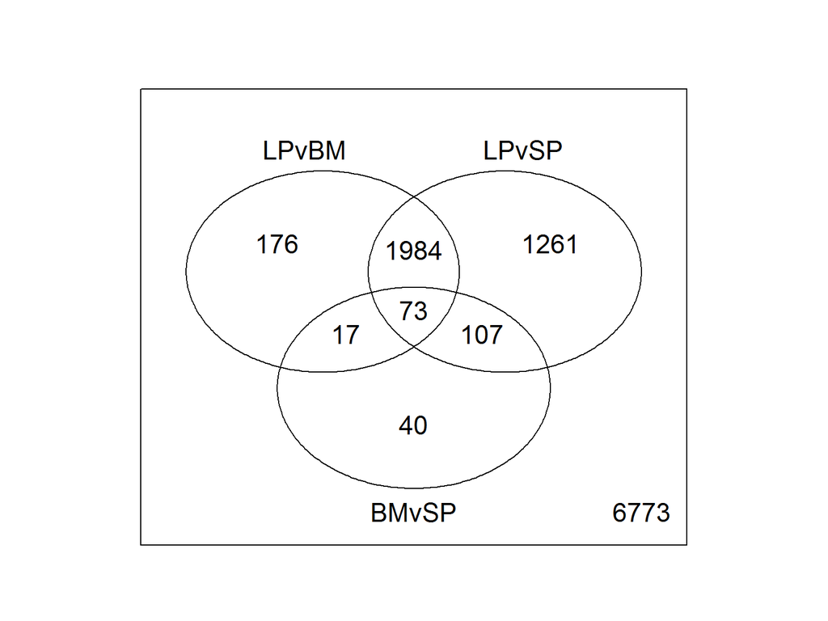

```r
results <- decideTests(ebFit, method="global", adjust.method="BH", p.value=0.05, lfc=0.59)
#results <- decideTests(ebFit, method="global", adjust.method="BH", p.value=0.05)
vennDiagram(results, include="both")
```

**Pull out and subset the differentially expressed genes.**

```r
diffProbes <- which(results[,1] !=0 | results[,2] !=0 | results[,3] !=0)
diffSymbols <- fit$genes$Symbol[results[,1] !=0 | results[,2] !=0 | results[,3] !=0]
diffEntrez <- fit$genes$Entrez[results[,1] !=0 | results[,2] !=0 | results[,3] !=0]
myEset.ALL <- new("ExpressionSet", exprs = filtered.matrix)
annotation(myEset.ALL) <- "mogene10sttranscriptcluster.db"
diffData <- filtered.eset[results[,1] !=0 | results[,2] !=0 | results[,3] !=0]
diffData <- exprs(diffData)
```

**Subset the data to include B220N PCs from LP Spleen and BM and create a heat map of these genes**  
Let’s look at the heat map without averaging the replicates first to get a better idea of the contribution of B220N.1 from the BM that was previously discussed.

#### **Figure 8. Heat map of Differentially expressed genes in B220 negative subsets**

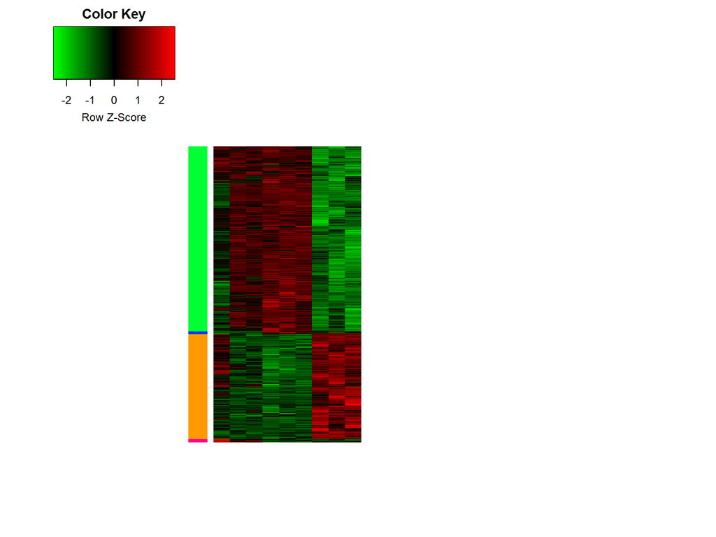

```r
diffData.subset <- diffData[,c(7,8,9,13,14,15,16,17,18)]
hr <- hclust(as.dist(1-cor(t(diffData.subset), method="pearson")), method="complete") #cluster rows by pearson correlation
hc <- hclust(as.dist(1-cor(diffData.subset, method="spearman")), method="complete") #cluster columns by spearman correlation
mycl <- cutree(hr, k=4)
mycolhc <- rainbow(length(unique(mycl)), start=0.1, end=0.9)
mycolhc <- mycolhc[as.vector(mycl)]
myheatcol <- greenred(75)
heatmap.2(diffData.subset, Rowv=as.dendrogram(hr), Colv=NA,
          col=myheatcol, scale="row", labRow=NA, labCol=NA,
          density.info="none", trace="none", RowSideColors=mycolhc,
          cexRow=1, cexCol=1, margins=c(8,30))
```

**Now average the biological replicates for a more clear heatmap**

#### **Figure 9. Heat map of Differentially expressed genes in B220 negative subsets**

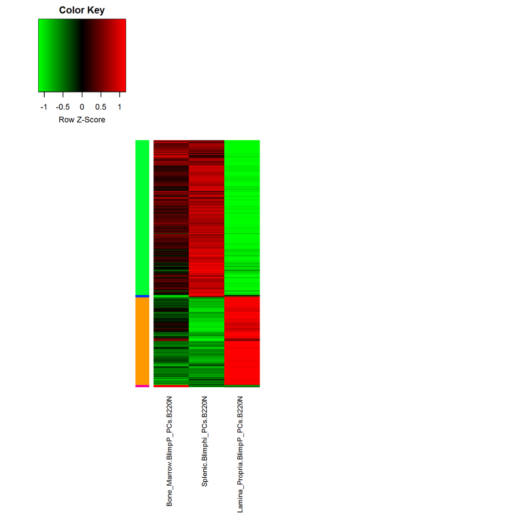

```r
colnames(diffData) <- myGroups
rownames(diffData) <- diffSymbols
diffData.AVG <- avearrays(diffData)
diffData.AVG.subset <- diffData.AVG[,c(3,5,6)]
heatmap.2(diffData.AVG.subset, Rowv=as.dendrogram(hr), Colv=NA,
          col=myheatcol, scale="row", labRow=NA, labCol=colnames(diffData.AVG.subset),
          density.info="none", trace="none", RowSideColors=mycolhc,
          cexRow=1, cexCol=1, margins=c(15,30))
```

**Take a look at the genes in each cluster and think about downstream enrichment analyses.**

```r
hr <- hclust(as.dist(1-cor(t(diffData.AVG.subset), method="pearson")), method="complete") #cluster rows by pearson correlation
hc <- hclust(as.dist(1-cor(diffData.AVG.subset, method="spearman")), method="complete") #cluster columns by spearman correlation

clid <- c(1)
ysub <- diffData.subset[names(mycl[mycl%in%clid]),]
hrsub <- hclust(as.dist(1-cor(t(ysub), method="pearson")), method="complete")
clusterIDs <- data.frame(Labels=rev(hrsub$labels[hrsub$order]))
clusterIDs_1 <- as.vector(t(clusterIDs))

clid <- c(2)
ysub <- diffData.subset[names(mycl[mycl%in%clid]),]
hrsub <- hclust(as.dist(1-cor(t(ysub), method="pearson")), method="complete")
clusterIDs <- data.frame(Labels=rev(hrsub$labels[hrsub$order]))
clusterIDs_2 <- as.vector(t(clusterIDs))

clid <- c(3)
ysub <- diffData.subset[names(mycl[mycl%in%clid]),]
hrsub <- hclust(as.dist(1-cor(t(ysub), method="pearson")), method="complete")
clusterIDs <- data.frame(Labels=rev(hrsub$labels[hrsub$order]))
clusterIDs_3 <- as.vector(t(clusterIDs))

clid <- c(4)
ysub <- diffData.subset[names(mycl[mycl%in%clid]),]
hrsub <- hclust(as.dist(1-cor(t(ysub), method="pearson")), method="complete")
clusterIDs <- data.frame(Labels=rev(hrsub$labels[hrsub$order]))
clusterIDs_4 <- as.vector(t(clusterIDs))
```

#### **Differential genes in each cluster**

| ClusterID | Phenotype | number of genes |
| --- | --- | --- |
| Cluster 1 | up in LP | 1296 |
| Cluster 2 | down in LP | 2289 |
| Cluster 3 | up in BM | 36 |
| Cluster 4 | up in SPL | 37 |

## Differentially Expressed Genes 2: B220+ and B220- PCs

**Now set up the experimental design and think about the question to ask in this analysis.**  
This time we’ll look at B220 positive verses negative in BM and Spleen

```r
design <- model.matrix(~0+myGroups)
colnames(design) <- levels(myGroups)
design
```

Define the contrast matrix and look at differentially expressed genes.

```r
fit <- lmFit(filtered.matrix, design)
fit$genes$Symbol <- getSYMBOL(probeList, "mogene10sttranscriptcluster.db")
fit$genes$Entrez <- getEG(probeList, "mogene10sttranscriptcluster.db")
contrast.matrix.B220 <- makeContrasts(BM = Bone_Marrow.BlimpP_PCs.B220N - Bone_Marrow.BlimpP_PCs.B220P,
                                      SP = Splenic.Blimphi_PCs.B220N - Splenic.Blimplow_PCs.B220P,
                                      BMvSP = Bone_Marrow.BlimpP_PCs.B220N - Splenic.Blimphi_PCs.B220N,
                                      levels=design)
fits <- contrasts.fit(fit, contrast.matrix.B220)
ebFit <- eBayes(fits)
```

**Let’s take a look at the top 20 differentially expressed genes between B220N vs B220P in the BM.**

```r
myTopHits <- topTable(ebFit, adjust ="BH", coef=1, number=20, sort.by="logFC")
row.names(myTopHits) <- myTopHits[,1]
myTopHits <- myTopHits[,c(3,4,6,7)]
knitr::kable(myTopHits)
```

|  | logFC | AveExpr | P.Value | adj.P.Val |
| --- | --- | --- | --- | --- |
| Prr11 | -2.600791 | 6.070410 | 0.0000205 | 0.0142506 |
| 2810417H13Rik | -2.360435 | 5.825327 | 0.0009263 | 0.0671002 |
| Ncapg | -2.268771 | 5.656746 | 0.0000000 | 0.0003858 |
| Samd9l | -2.263077 | 5.956477 | 0.0000028 | 0.0086732 |
| Top2a | -2.249430 | 6.511040 | 0.0004025 | 0.0471228 |
| Kif11 | -2.172195 | 5.596486 | 0.0001021 | 0.0273212 |
| Cdkn3 | -2.155774 | 5.926671 | 0.0000237 | 0.0154548 |
| Casc5 | -2.127347 | 5.203823 | 0.0001146 | 0.0282446 |
| Smc2 | -2.105534 | 4.855630 | 0.0000691 | 0.0236995 |
| Birc5 | -2.056770 | 6.522428 | 0.0009937 | 0.0681471 |
| Hmmr | -2.038312 | 4.652314 | 0.0003026 | 0.0409255 |
| Cenpe | -2.024122 | 4.168182 | 0.0000315 | 0.0173086 |
| Mki67 | -2.000671 | 7.602688 | 0.0005751 | 0.0517115 |
| Gm10796 | -1.977119 | 4.931081 | 0.0010516 | 0.0689858 |
| Xist | -1.970199 | 6.190671 | 0.3492558 | 0.6277938 |
| Marcks | -1.968983 | 5.511916 | 0.0000907 | 0.0262802 |
| Cenpk | -1.916631 | 4.772934 | 0.0000344 | 0.0179515 |
| Arhgap11a | -1.914451 | 4.993368 | 0.0001487 | 0.0302640 |
| Cenpw | -1.898259 | 5.963103 | 0.0066764 | 0.1374032 |
| C330027C09Rik | -1.895588 | 4.503307 | 0.0000205 | 0.0142506 |

**…and now between B220N vs B220P in the Spl…**

```r
myTopHits <- topTable(ebFit, adjust ="BH", coef=2, number=20, sort.by="logFC")
row.names(myTopHits) <- myTopHits[,1]
myTopHits <- myTopHits[,c(3,4,6,7)]
knitr::kable(myTopHits)
```

|  | logFC | AveExpr | P.Value | adj.P.Val |
| --- | --- | --- | --- | --- |
| Cxcr3 | -2.659563 | 7.512542 | 0.0000067 | 0.0031368 |
| Ccna2 | -2.554423 | 7.210591 | 0.0001304 | 0.0175587 |
| Cenpw | -2.544501 | 5.963103 | 0.0006745 | 0.0360081 |
| Ccnb2 | -2.478093 | 7.169728 | 0.0000009 | 0.0014066 |
| Speer1-ps1 | -2.461527 | 5.486569 | 0.0000001 | 0.0003133 |
| Top2a | -2.456160 | 6.511040 | 0.0001691 | 0.0182335 |
| I830127L07Rik | -2.437643 | 7.047737 | 0.0000124 | 0.0044345 |
| C330027C09Rik | -2.237279 | 4.503307 | 0.0000027 | 0.0019755 |
| Rrm2 | -2.185276 | 6.854596 | 0.0002492 | 0.0206270 |
| Birc5 | -2.181504 | 6.522428 | 0.0005880 | 0.0335670 |
| Cox6a2 | 2.170931 | 7.206453 | 0.0001393 | 0.0179066 |
| Bub1 | -2.158885 | 3.967770 | 0.0002455 | 0.0204902 |
| 2810417H13Rik | -2.152266 | 5.825327 | 0.0020024 | 0.0656813 |
| Cdkn3 | -2.131752 | 5.926671 | 0.0000270 | 0.0070404 |
| Plk1 | -2.112114 | 5.404906 | 0.0010066 | 0.0426833 |
| Stil | -2.105292 | 4.267078 | 0.0000058 | 0.0029056 |
| Hmmr | -2.099517 | 4.652314 | 0.0002260 | 0.0202363 |
| Prg2 | 2.098340 | 9.779345 | 0.0000000 | 0.0000078 |
| Arhgap11a | -2.094950 | 4.993368 | 0.0000567 | 0.0111345 |
| Kif11 | -2.088293 | 5.596486 | 0.0001542 | 0.0182335 |

**…and finally between BM and Spleen B220N.**

```r
myTopHits <- topTable(ebFit, adjust ="BH", coef=3, number=20, sort.by="logFC")
row.names(myTopHits) <- myTopHits[,1]
myTopHits <- myTopHits[,c(3,4,6,7)]
knitr::kable(myTopHits)
```

|  | logFC | AveExpr | P.Value | adj.P.Val |
| --- | --- | --- | --- | --- |
| Camp | 4.226134 | 7.474374 | 0.0000204 | 0.0532411 |
| Ngp | 4.013620 | 6.320623 | 0.0000556 | 0.0558541 |
| S100a8 | 3.884341 | 9.003908 | 0.0004968 | 0.1359324 |
| S100a9 | 3.792425 | 8.896159 | 0.0000948 | 0.0660801 |
| Lcn2 | 3.762065 | 6.318030 | 0.0003163 | 0.1218248 |
| Retnlg | 3.319330 | 6.947406 | 0.0021214 | 0.2377735 |
| Mpo | 3.247564 | 5.581281 | 0.0000897 | 0.0660801 |
| Chil3 | 3.088146 | 5.320545 | 0.0025242 | 0.2377735 |
| Ifitm6 | 2.548911 | 5.296799 | 0.0185243 | 0.4173375 |
| Ltf | 2.349185 | 5.245582 | 0.0118634 | 0.3693948 |
| Elane | 1.951168 | 4.927956 | 0.0066362 | 0.3204709 |
| Alox5ap | 1.926839 | 5.954010 | 0.0091774 | 0.3528797 |
| Prtn3 | 1.893833 | 4.910396 | 0.0003387 | 0.1218248 |
| Hp | 1.892652 | 4.886293 | 0.0207325 | 0.4377741 |
| Mmp8 | 1.775127 | 4.152329 | 0.0173082 | 0.4038974 |
| Plekhf1 | 1.768204 | 5.429450 | 0.0000447 | 0.0558541 |
| D730005E14Rik | -1.759264 | 4.929671 | 0.0055348 | 0.2960695 |
| Wfdc21 | 1.759028 | 5.406629 | 0.0067267 | 0.3218639 |
| Erc1 | 1.752971 | 5.555207 | 0.0003350 | 0.1218248 |
| Mt1 | 1.750117 | 9.325127 | 0.0040936 | 0.2772326 |

**Then we’ll create a ven diagram showing differential gene expression and overlap between these groups.**

#### **Figure 7. Differentially expressed genes by subset**

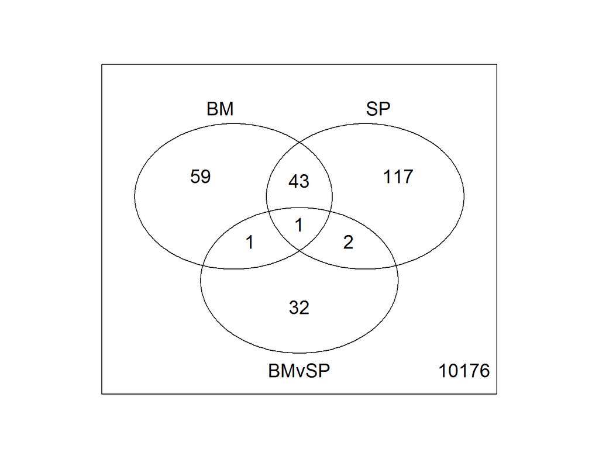

```r
results <- decideTests(ebFit, method="global", adjust.method="BH", p.value=0.05, lfc=0.59)
#results <- decideTests(ebFit, method="global", adjust.method="BH", p.value=0.05)
vennDiagram(results, include="both")
```

**Pull out and subset the differentially expressed genes.**

```r
diffProbes <- which(results[,1] !=0 | results[,2] !=0 | results[,3] !=0)
diffSymbols <- fit$genes$Symbol[results[,1] !=0 | results[,2] !=0 | results[,3] !=0]
diffEntrez <- fit$genes$Entrez[results[,1] !=0 | results[,2] !=0 | results[,3] !=0]
myEset.ALL <- new("ExpressionSet", exprs = filtered.matrix)
annotation(myEset.ALL) <- "mogene10sttranscriptcluster.db"
diffData <- filtered.eset[results[,1] !=0 | results[,2] !=0 | results[,3] !=0]
diffData <- exprs(diffData)
```

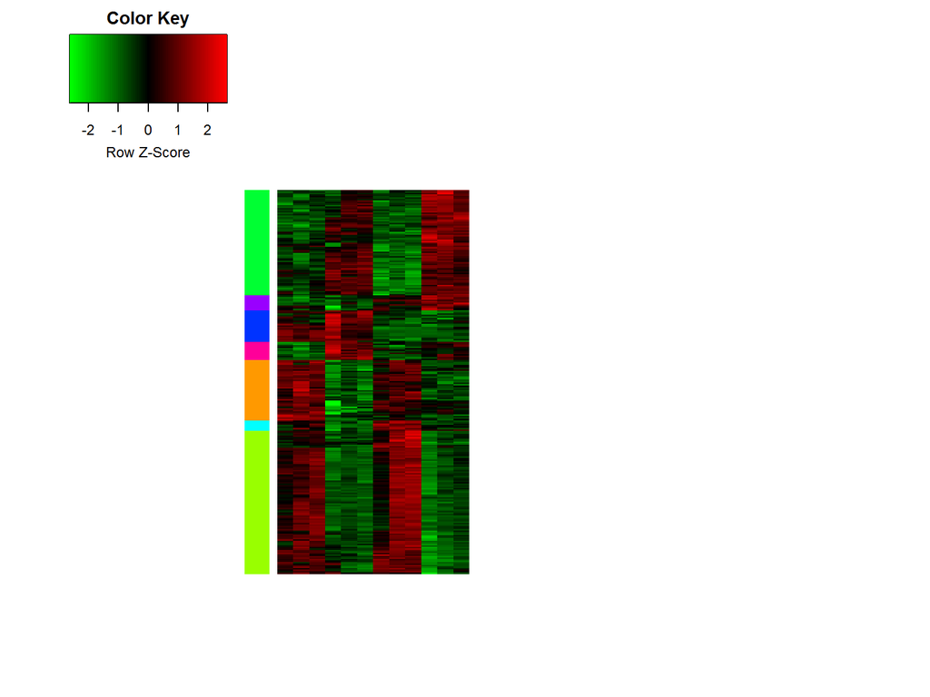

```r
diffData.subset <- diffData[,c(4,5,6,7,8,9,10,11,12,13,14,15)]
hr <- hclust(as.dist(1-cor(t(diffData.subset), method="pearson")), method="complete") #cluster rows by pearson correlation
hc <- hclust(as.dist(1-cor(diffData.subset, method="spearman")), method="complete") #cluster columns by spearman correlation
mycl <- cutree(hr, k=7)
mycolhc <- rainbow(length(unique(mycl)), start=0.1, end=0.9)
mycolhc <- mycolhc[as.vector(mycl)]
myheatcol <- greenred(75)
heatmap.2(diffData.subset, Rowv=as.dendrogram(hr), Colv=NA,
          col=myheatcol, scale="row", labRow=NA, labCol=NA,
          density.info="none", trace="none", RowSideColors=mycolhc,
          cexRow=1, cexCol=1, margins=c(8,30))
```

**Now average the biological replicates for a more clear heatmap**

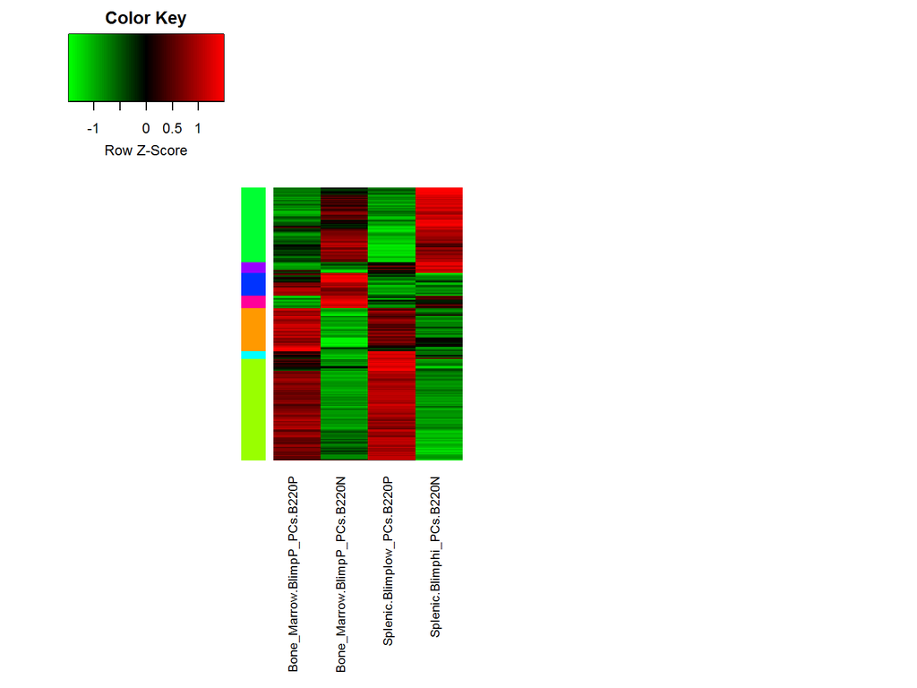

```r
colnames(diffData) <- myGroups
rownames(diffData) <- diffSymbols
diffData.AVG <- avearrays(diffData)
diffData.AVG.subset <- diffData.AVG[,c(2,3,4,5)]
heatmap.2(diffData.AVG.subset, Rowv=as.dendrogram(hr), Colv=NA,
          col=myheatcol, scale="row", labRow=NA, labCol=colnames(diffData.AVG.subset),
          density.info="none", trace="none", RowSideColors=mycolhc,
          cexRow=1, cexCol=1, margins=c(15,30))
```

**Take a look at the genes in each cluster and think about downstream enrichment analyses.**

```r
hr <- hclust(as.dist(1-cor(t(diffData.AVG.subset), method="pearson")), method="complete") #cluster rows by pearson correlation
hc <- hclust(as.dist(1-cor(diffData.AVG.subset, method="spearman")), method="complete") #cluster columns by spearman correlation

clid <- c(1)
ysub <- diffData.subset[names(mycl[mycl%in%clid]),]
hrsub <- hclust(as.dist(1-cor(t(ysub), method="pearson")), method="complete")
clusterIDs <- data.frame(Labels=rev(hrsub$labels[hrsub$order]))
clusterIDs2_1 <- as.vector(t(clusterIDs))

clid <- c(2)
ysub <- diffData.subset[names(mycl[mycl%in%clid]),]
hrsub <- hclust(as.dist(1-cor(t(ysub), method="pearson")), method="complete")
clusterIDs <- data.frame(Labels=rev(hrsub$labels[hrsub$order]))
clusterIDs2_2 <- as.vector(t(clusterIDs))

clid <- c(3)
ysub <- diffData.subset[names(mycl[mycl%in%clid]),]
hrsub <- hclust(as.dist(1-cor(t(ysub), method="pearson")), method="complete")
clusterIDs <- data.frame(Labels=rev(hrsub$labels[hrsub$order]))
clusterIDs2_3 <- as.vector(t(clusterIDs))

clid <- c(4)
ysub <- diffData.subset[names(mycl[mycl%in%clid]),]
hrsub <- hclust(as.dist(1-cor(t(ysub), method="pearson")), method="complete")
clusterIDs <- data.frame(Labels=rev(hrsub$labels[hrsub$order]))
clusterIDs2_4 <- as.vector(t(clusterIDs))

clid <- c(5)
ysub <- diffData.subset[names(mycl[mycl%in%clid]),]
hrsub <- hclust(as.dist(1-cor(t(ysub), method="pearson")), method="complete")
clusterIDs <- data.frame(Labels=rev(hrsub$labels[hrsub$order]))
clusterIDs2_5 <- as.vector(t(clusterIDs))


clid <- c(6)
ysub <- diffData.subset[names(mycl[mycl%in%clid]),]
hrsub <- hclust(as.dist(1-cor(t(ysub), method="pearson")), method="complete")
clusterIDs <- data.frame(Labels=rev(hrsub$labels[hrsub$order]))
clusterIDs2_6 <- as.vector(t(clusterIDs))

clid <- c(7)
ysub <- diffData.subset[names(mycl[mycl%in%clid]),]
hrsub <- hclust(as.dist(1-cor(t(ysub), method="pearson")), method="complete")
clusterIDs <- data.frame(Labels=rev(hrsub$labels[hrsub$order]))
clusterIDs2_7 <- as.vector(t(clusterIDs))
```

#### **Differential genes in each cluster**

| ClusterID | Phenotype | number of genes |
| --- | --- | --- |
| Cluster 1 | up in B220P (BM>Spl) | 40 |
| Cluster 2 | up in B220P (Spl>BM) | 95 |
| Cluster 3 | up in B220N (Spl>BM) | 70 |
| Cluster 4 | up in B220P (Spl>BM) | 7 |
| Cluster 5 | up in BM | 21 |
| Cluster 6 | up in SPL | 10 |
| Cluster 7 | up in B220N (BM>Spl) | 12 |